# Intro to R with NYC 311 Data

This is an R Markdown file.

Useful resources for R Markdown and Knitr: http://rmarkdown.rstudio.com/ https://www.rstudio.com/resources/cheatsheets/

Load packages.

Either require(package.name) or library(package.name) will work.

```r
library(tidyverse)
library(cowplot)
library(viridis)
library(lubridate)
library(stringr)
```

Note the warnings as some functions are masked as one package after the other is loaded. If there is an issue with a masked function, call it by package name: package_name::function().

To get help at any point, type: ?package_name or ?function_name to console to bring up the help.

### Data import:

- read_csv() is part of the readr package, and will import the data as a tibble
- read.csv() is bart of base r and will import the data as a data.frame

```r
call.data <- read_csv(file = "311service_2015calls_10per.csv", col_names = TRUE)
call.data <- call.data %>%
  arrange(desc(`Unique Key`))
call.data
```

```
## # A tibble: 228,221 x 16
##    `Unique Key`         `Created Date`          `Closed Date` Agency
##           <int>                  <chr>                  <chr>  <chr>
##  1     36002467 10/06/2015 12:00:00 AM 10/10/2015 12:00:00 AM    DEP
##  2     35285098 11/18/2015 09:39:16 AM 01/19/2017 12:00:00 AM    DOB
##  3     33497115 06/09/2015 12:00:00 AM 07/08/2015 12:00:00 AM    DEP
##  4     33378674 06/21/2015 01:20:01 PM                   <NA>    DOT
##  5     33372655 06/21/2015 04:58:06 PM                   <NA>    DOT
##  6     33370468 06/21/2015 08:27:25 PM                   <NA>    DOT
##  7     33350985 06/19/2015 06:59:57 PM                   <NA>    DOT
##  8     33349216 06/21/2015 11:15:27 AM                   <NA>    DOT
##  9     33349158 06/21/2015 08:17:41 PM                   <NA>    DOT
## 10     33347477 06/20/2015 05:03:09 AM                   <NA>    DOT
## # ... with 228,211 more rows, and 12 more variables: `Agency Name` <chr>,
## #   `Complaint Type` <chr>, Descriptor <chr>, `Location Type` <chr>,
## #   `Incident Zip` <int>, `Incident Address` <chr>, `Street Name` <chr>,
## #   City <chr>, Status <chr>, `Resolution Description` <chr>,
## #   Latitude <dbl>, Longitude <dbl>
```

```r
vrbl.names <- str_to_lower(colnames(call.data))
vrbl.names <- gsub(" ", ".", vrbl.names)
colnames(call.data) <- vrbl.names
call.data
```

```
## # A tibble: 228,221 x 16
##    unique.key           created.date            closed.date agency
##         <int>                  <chr>                  <chr>  <chr>
##  1   36002467 10/06/2015 12:00:00 AM 10/10/2015 12:00:00 AM    DEP
##  2   35285098 11/18/2015 09:39:16 AM 01/19/2017 12:00:00 AM    DOB
##  3   33497115 06/09/2015 12:00:00 AM 07/08/2015 12:00:00 AM    DEP
##  4   33378674 06/21/2015 01:20:01 PM                   <NA>    DOT
##  5   33372655 06/21/2015 04:58:06 PM                   <NA>    DOT
##  6   33370468 06/21/2015 08:27:25 PM                   <NA>    DOT
##  7   33350985 06/19/2015 06:59:57 PM                   <NA>    DOT
##  8   33349216 06/21/2015 11:15:27 AM                   <NA>    DOT
##  9   33349158 06/21/2015 08:17:41 PM                   <NA>    DOT
## 10   33347477 06/20/2015 05:03:09 AM                   <NA>    DOT
## # ... with 228,211 more rows, and 12 more variables: agency.name <chr>,
## #   complaint.type <chr>, descriptor <chr>, location.type <chr>,
## #   incident.zip <int>, incident.address <chr>, street.name <chr>,
## #   city <chr>, status <chr>, resolution.description <chr>,
## #   latitude <dbl>, longitude <dbl>
```

```r
rm(vrbl.names)
```

rm(list=ls()) will all variables in the global environment.

```r
# which variables have missing values?
sapply(call.data, anyNA)
```

```
##             unique.key           created.date            closed.date
##                  FALSE                  FALSE                   TRUE
##                 agency            agency.name         complaint.type
##                  FALSE                  FALSE                  FALSE
##             descriptor          location.type           incident.zip
##                   TRUE                   TRUE                   TRUE
##       incident.address            street.name                   city
##                   TRUE                   TRUE                   TRUE
##                 status resolution.description               latitude
##                  FALSE                   TRUE                   TRUE
##              longitude
##                   TRUE
```

```r
# how to check how many missing values in one column?
sum(is.na(call.data$closed.date))
```

```
## [1] 6485
```

```r
sum(is.na(call.data$closed.date)) / nrow(call.data) * 100
```

```
## [1] 2.841544
```

```r
# which agencies respond to 311 service calls?
sort(unique(call.data$agency))
```

```
##  [1] "3-1-1"      "AJC"        "DCA"        "DEP"        "DFTA"
##  [6] "DHS"        "DOB"        "DOC"        "DOE"        "DOF"
## [11] "DOHMH"      "DOITT"      "DOP"        "DOT"        "DPR"
## [16] "DSNY"       "EDC"        "FDNY"       "HPD"        "HRA"
## [21] "LAW"        "MOIA"       "MOVA"       "NYCEM"      "NYCHA"
## [26] "NYCSERVICE" "NYPD"       "OATH"       "OCME"       "OPS"
## [31] "TLC"
```

```r
length(unique(call.data$agency))
```

```
## [1] 31
```

```r
length(unique(call.data$agency.name))
```

```
## [1] 251
```

```r
head(unique(call.data$agency.name), n = 20)
```

```
##  [1] "Department of Environmental Protection"
##  [2] "Department of Buildings"
##  [3] "Department of Transportation"
##  [4] "Department of Health and Mental Hygiene"
##  [5] "Department of Housing Preservation and Development"
##  [6] "Department of Parks and Recreation"
##  [7] "New York City Police Department"
##  [8] "Department for the Aging"
##  [9] "HRA Benefit Card Replacement"
## [10] "Queens East 10"
## [11] "BCC - Brooklyn South"
## [12] "BCC - Staten Island"
## [13] "A - Staten Island"
## [14] "Senior Citizen Rent Increase Exemption Unit"
## [15] "BCC - Bronx"
## [16] "Taxi and Limousine Commission"
## [17] "BCC - Queens West"
## [18] "Operations Unit - Department of Homeless Services"
## [19] "Department of Sanitation"
## [20] "Department of Finance"
```

```r
call.data %>%
  select(agency:agency.name) %>%
  mutate(combo = paste(agency, agency.name, sep = " / ")) %>%
  group_by(combo) %>%
  summarise(unq = n()) %>%
  #arrange(combo) %>%
  arrange(desc(unq)) %>%
  head(n = 20)
```

```
## # A tibble: 20 x 2
##                                                       combo   unq
##                                                       <chr> <int>
##  1 HPD / Department of Housing Preservation and Development 62900
##  2                   NYPD / New York City Police Department 58100
##  3                       DOT / Department of Transportation 31685
##  4             DEP / Department of Environmental Protection 18336
##  5                 DPR / Department of Parks and Recreation  8780
##  6                            DOB / Department of Buildings  8180
##  7          DOHMH / Department of Health and Mental Hygiene  5745
##  8                              DOF / Department of Finance  2869
##  9                      TLC / Taxi and Limousine Commission  2623
## 10                       HRA / HRA Benefit Card Replacement  2312
## 11                     DCA / Department of Consumer Affairs  1985
## 12                              DSNY / BCC - Brooklyn South  1583
## 13                              DSNY / BCC - Brooklyn North  1385
## 14                          DSNY / Department of Sanitation  1354
## 15                                      DSNY / A - Brooklyn  1239
## 16                                        DSNY / A - Queens  1106
## 17                                 DSNY / BCC - Queens East  1076
## 18                               DSNY / BCC - Staten Island   996
## 19                          DFTA / Department for the Aging   956
## 20                            DOF / Refunds and Adjustments   871
```

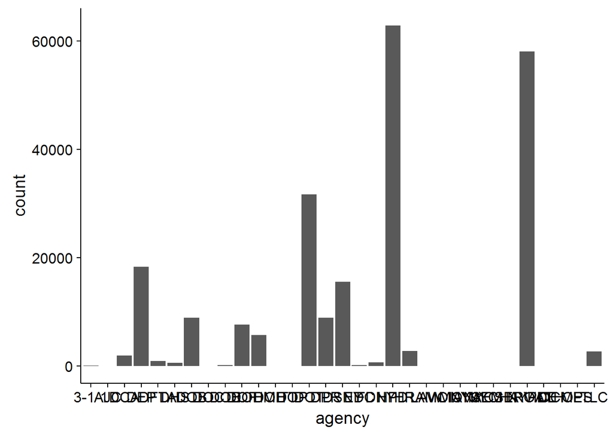

```r
  #ggplot(aes(x = unq)) +
  #geom_histogram(bins = 100)

ggplot(data = call.data, aes(x = agency)) +
  geom_bar(stat = "count")
```

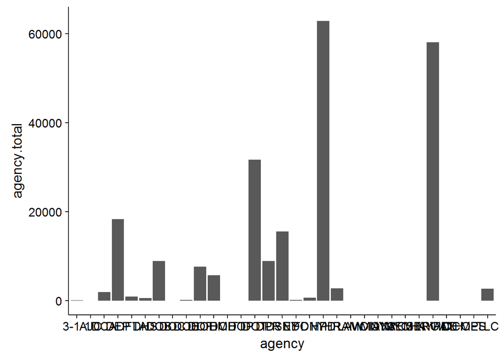

```r
call.data %>%
  group_by(agency) %>%
  summarise(agency.total = n()) %>%
  arrange(desc(agency.total)) %>%
  ggplot(aes(x = agency, y = agency.total)) +
  geom_bar(stat = "identity")
```

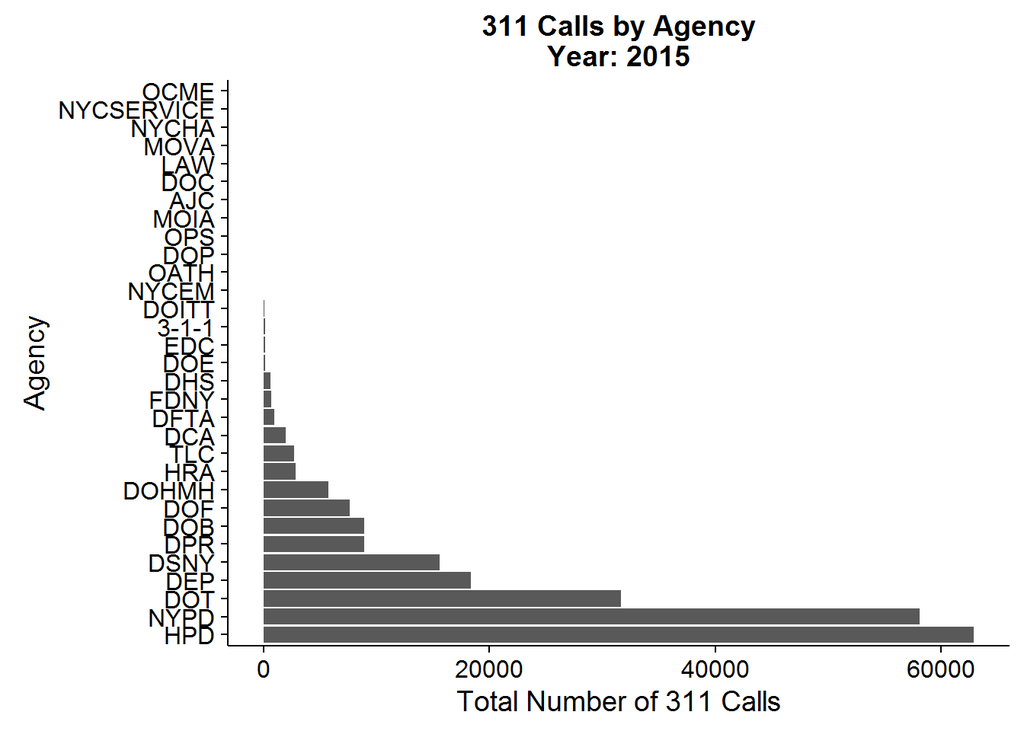

```r
agency.info <- call.data %>%
  group_by(agency) %>%
  summarise(agency.total = n()) %>%
  arrange(desc(agency.total)) %>%
  mutate(ord.agency = factor(agency, levels = agency))

agency.info %>%
  ggplot(aes(x = ord.agency, y = agency.total)) +
  geom_bar(stat = "identity") +
  coord_flip() +
  ylab("Total Number of 311 Calls") +
  xlab("Agency") +
  ggtitle("311 Calls by Agency\nYear: 2015")
```

Where do calls originate?

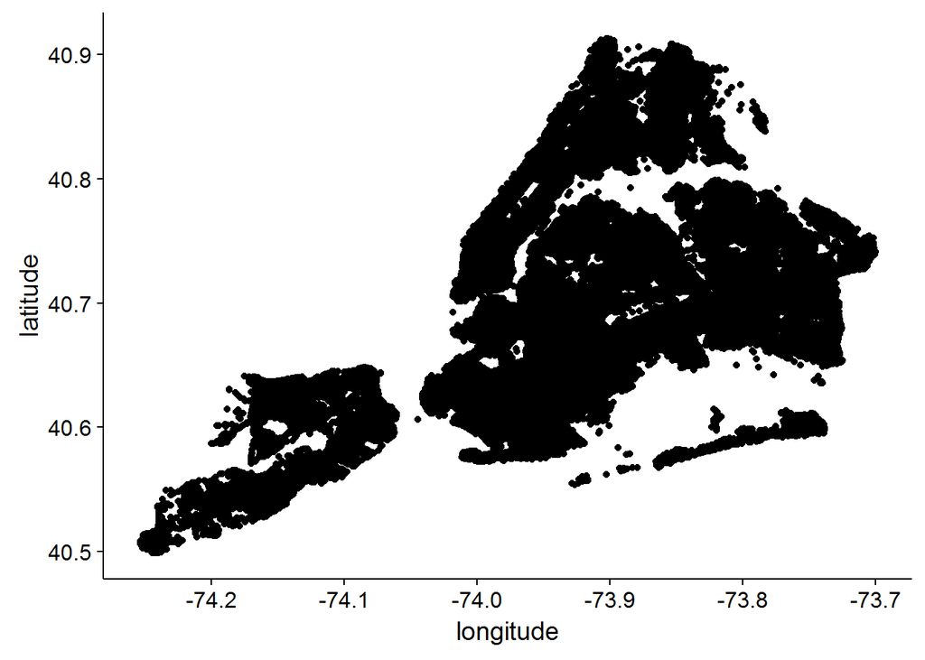

```r
# plot Lat v Long
call.data %>%
  ggplot(aes(x = longitude, y = latitude)) +
  geom_point()
```

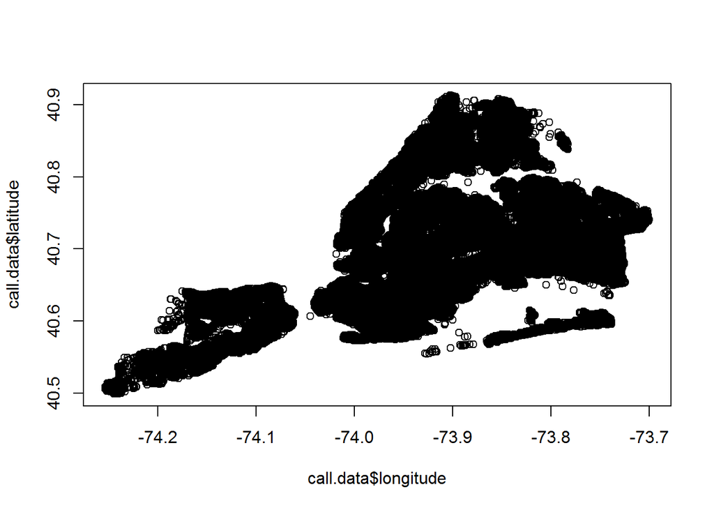

```r
plot(call.data$longitude, call.data$latitude, type = "p")
```

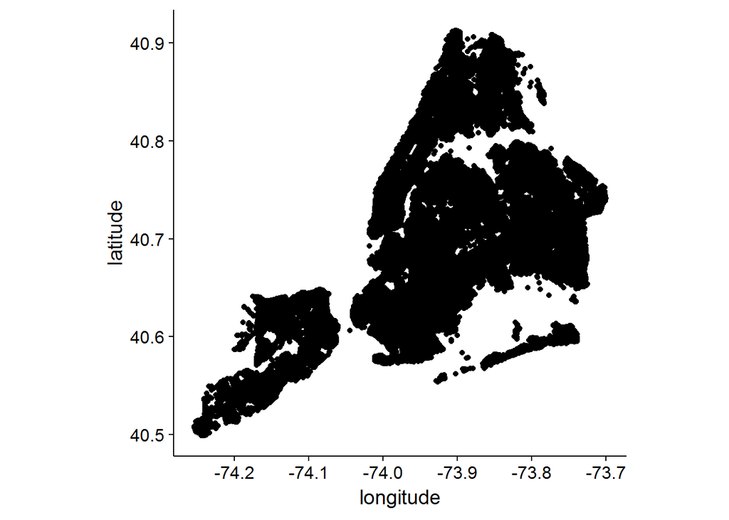

```r
map.base <- call.data %>%
  ggplot(aes(x = longitude, y = latitude)) +
  coord_quickmap()

map.base +
  geom_point()
```

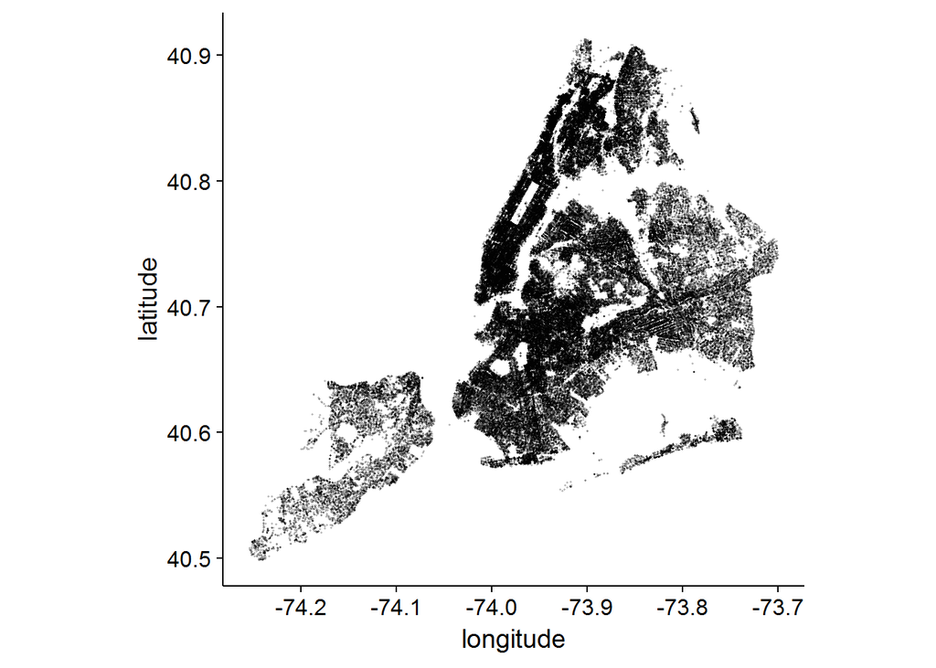

```r
map.base +
  geom_point(alpha = 0.2, size = 0.25)
```

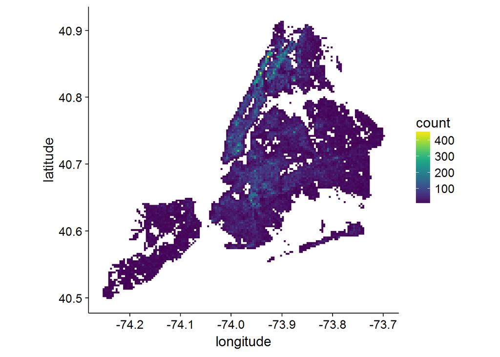

```r
map.base +
  geom_bin2d(bins = 150) +
  scale_fill_viridis(option = "D")
```

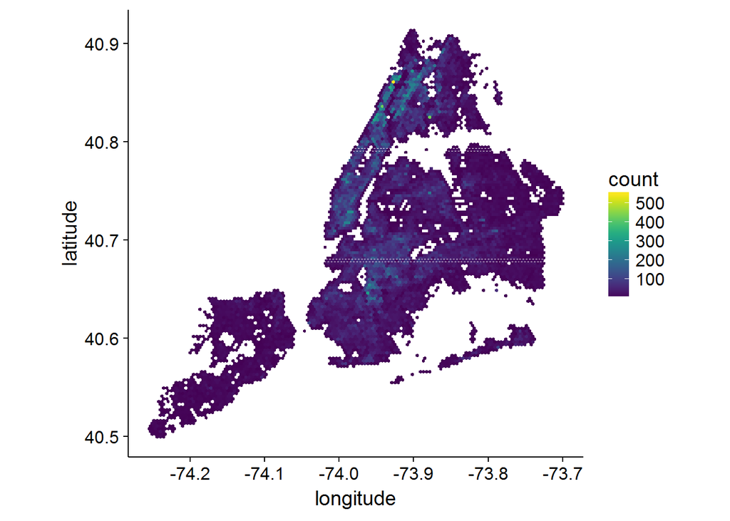

```r
map.base +
  geom_hex(bins = 130) +
  scale_fill_viridis(option = "D")
```

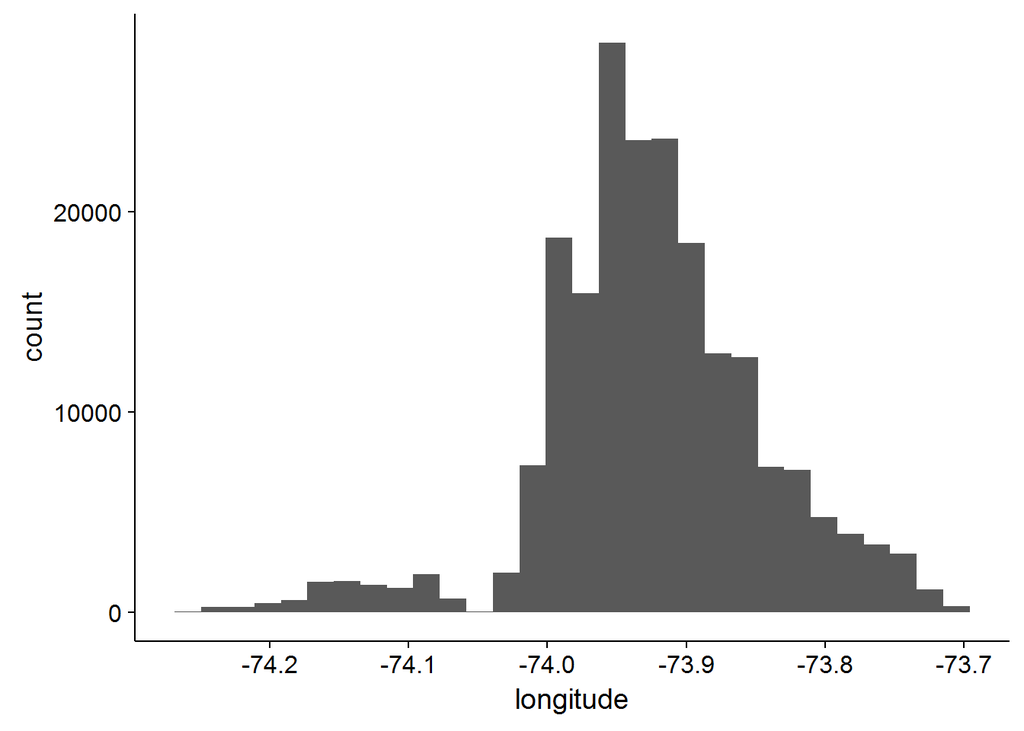

```r
call.data %>%
  ggplot(aes(x = longitude)) +
  geom_histogram() #+
```

```r
  #geom_histogram(aes(y = ..density..), alpha = 0.5) +
  #geom_density(color = "red", size = 5)
```

Can we get more useful information relating to location, such as: are certain types of calls more common in different places in NYC?

Six agencies account for 85% of the service calls:

```r
agency.info <- agency.info %>%
  arrange(desc(agency.total))
cumsum(agency.info$agency.total) / sum(agency.info$agency.total)
```

```
##  [1] 0.2757021 0.5302842 0.6691190 0.7495498 0.8178345 0.8570202 0.8959868
##  [8] 0.9294456 0.9547412 0.9671021 0.9788757 0.9875734 0.9917624 0.9948734
## [15] 0.9976295 0.9983437 0.9990141 0.9996100 0.9998072 0.9998773 0.9999343
## [22] 0.9999474 0.9999606 0.9999693 0.9999737 0.9999781 0.9999825 0.9999869
## [29] 0.9999912 0.9999956 1.0000000
```

```r
head(agency.info, n = 7)
```

```
## # A tibble: 7 x 3
##   agency agency.total ord.agency
##    <chr>        <int>     <fctr>
## 1    HPD        62921        HPD
## 2   NYPD        58101       NYPD
## 3    DOT        31685        DOT
## 4    DEP        18356        DEP
## 5   DSNY        15584       DSNY
## 6    DPR         8943        DPR
## 7    DOB         8893        DOB
```

```r
top.six <- call.data %>%
  filter(agency %in% agency.info$agency[1:6]) %>%
  mutate(agency = factor(agency, levels = agency.info$ord.agency))
length(unique(top.six$agency))
```

```
## [1] 6
```

```r
unique(top.six$agency)
```

```
## [1] DEP  DOT  HPD  DPR  NYPD DSNY
## 31 Levels: HPD NYPD DOT DEP DSNY DPR DOB DOF DOHMH HRA TLC DCA ... OCME
```

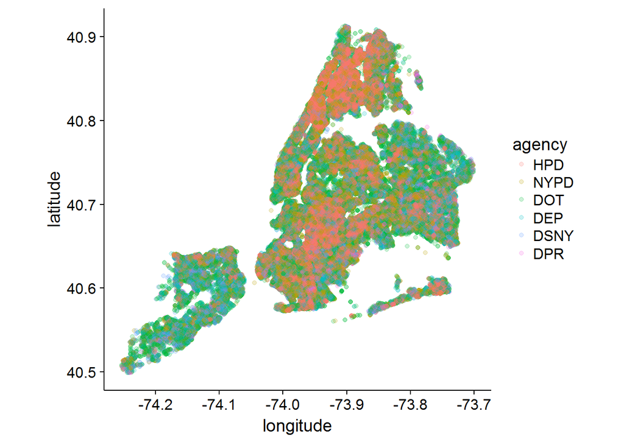

```r
top.six %>%
  ggplot(aes(x = longitude, y = latitude, color = agency)) +
  geom_point(alpha = 0.2) +
  coord_quickmap()
```

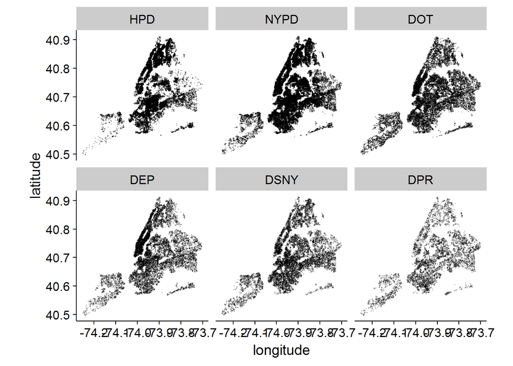

```r
top.six %>%
  ggplot(aes(x = longitude, y = latitude)) +
  geom_point(alpha = 0.2, size = 0.25) +
  coord_quickmap() +
  facet_wrap(~agency)
```

What are they typical HPD complaints?

```r
hpd.calls <- top.six %>%
  filter(agency == "HPD")
length(unique(call.data$complaint.type))
```

```
## [1] 216
```

```r
call.data %>%
  group_by(complaint.type) %>%
  summarise(tot = n()) %>%
  arrange(desc(tot))
```

```
## # A tibble: 216 x 2
##            complaint.type   tot
##                     <chr> <int>
##  1         HEAT/HOT WATER 22615
##  2    Noise - Residential 20875
##  3       Street Condition 12332
##  4       Blocked Driveway 10072
##  5 Street Light Condition  9710
##  6        Illegal Parking  9335
##  7   UNSANITARY CONDITION  8338
##  8           Water System  7127
##  9          PAINT/PLASTER  6928
## 10                  Noise  5636
## # ... with 206 more rows
```

```r
hpd.calls %>%
  group_by(complaint.type) %>%
  summarise(tot = n()) %>%
  arrange(desc(tot))
```

```
## # A tibble: 14 x 2
##            complaint.type   tot
##                     <chr> <int>
##  1         HEAT/HOT WATER 22615
##  2   UNSANITARY CONDITION  8338
##  3          PAINT/PLASTER  6928
##  4               PLUMBING  5593
##  5            DOOR/WINDOW  3924
##  6             WATER LEAK  3598
##  7               ELECTRIC  2991
##  8        FLOORING/STAIRS  2758
##  9                GENERAL  2664
## 10 HPD Literature Request  1196
## 11              APPLIANCE  1130
## 12                 SAFETY   940
## 13       OUTSIDE BUILDING   156
## 14               ELEVATOR    90
```

```r
hpd.calls %>%
  group_by(descriptor) %>%
  summarise(tot = n()) %>%
  arrange(desc(tot))
```

```
## # A tibble: 63 x 2
##         descriptor   tot
##              <chr> <int>
##  1 ENTIRE BUILDING 14681
##  2  APARTMENT ONLY  7934
##  3           PESTS  4098
##  4            WALL  3364
##  5         CEILING  3304
##  6            MOLD  2636
##  7           FLOOR  2585
##  8            DOOR  1784
##  9      HEAVY FLOW  1669
## 10      BASIN/SINK  1592
## # ... with 53 more rows
```

How does the type of complaint change over the course of the year?

```r
complaints <- call.data %>%
  group_by(complaint.type) %>%
  summarise(tot = n()) %>%
  arrange(desc(tot))

head(call.data$created.date)
```

```
## [1] "10/06/2015 12:00:00 AM" "11/18/2015 09:39:16 AM"
## [3] "06/09/2015 12:00:00 AM" "06/21/2015 01:20:01 PM"
## [5] "06/21/2015 04:58:06 PM" "06/21/2015 08:27:25 PM"
```

```r
pop.comp <- call.data %>%
  filter(complaint.type %in% complaints$complaint.type[1:6]) %>%
  separate(created.date, c("date", "time", "tod"), sep = " ") %>%
  mutate(date = mdy(date))

pop.comp
```

```
## # A tibble: 84,939 x 18
##    unique.key       date     time   tod closed.date agency
##         <int>     <date>    <chr> <chr>       <chr>  <chr>
##  1   33378674 2015-06-21 01:20:01    PM        <NA>    DOT
##  2   33372655 2015-06-21 04:58:06    PM        <NA>    DOT
##  3   33370468 2015-06-21 08:27:25    PM        <NA>    DOT
##  4   33350985 2015-06-19 06:59:57    PM        <NA>    DOT
##  5   33349216 2015-06-21 11:15:27    AM        <NA>    DOT
##  6   33349158 2015-06-21 08:17:41    PM        <NA>    DOT
##  7   33347477 2015-06-20 05:03:09    AM        <NA>    DOT
##  8   33346538 2015-06-20 03:29:36    PM        <NA>    DOT
##  9   33345751 2015-06-21 08:21:22    PM        <NA>    DOT
## 10   33344847 2015-06-20 06:11:25    PM        <NA>    DOT
## # ... with 84,929 more rows, and 12 more variables: agency.name <chr>,
## #   complaint.type <chr>, descriptor <chr>, location.type <chr>,
## #   incident.zip <int>, incident.address <chr>, street.name <chr>,
## #   city <chr>, status <chr>, resolution.description <chr>,
## #   latitude <dbl>, longitude <dbl>
```

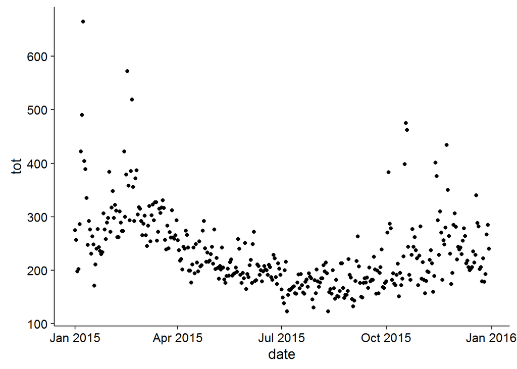

```r
pop.comp %>%
  group_by(date) %>%
  summarise(tot = n()) %>%
  ggplot(aes(x = date, y = tot)) +
  geom_point()
```

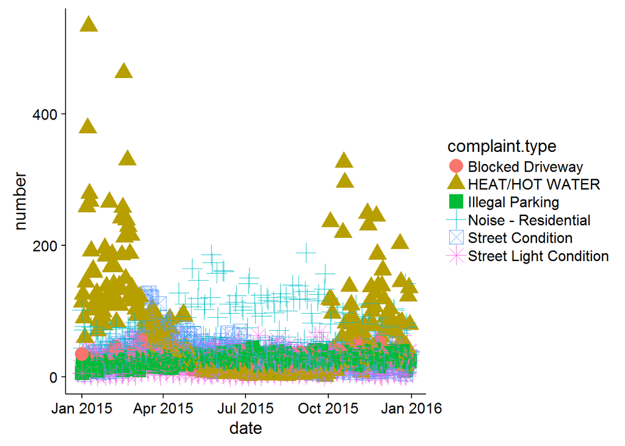

```r
pop.comp %>%
  select(date, complaint.type) %>%
  group_by(date, complaint.type) %>%
  mutate(number = n()) %>%
  distinct() %>%
  ggplot(aes(x = date, y = number, color = complaint.type, shape = complaint.type)) +
  geom_point(size = 5)
```

http://www.cookbook-r.com/Graphs/ http://r-statistics.co/Top50-Ggplot2-Visualizations-MasterList-R-Code.html http://www.sthda.com/english/wiki/ggplot2-essentials